# Études qualitatives sur le web - Séance 3

SB

21/10/2020

```r
knitr::opts_chunk$set(
  echo = TRUE,
  message = FALSE,
  warning = FALSE)
library(readxl)
library(tidyverse)
library(quanteda)
library(quanteda.textstats)
library(quanteda.textplots)
library(RColorBrewer)
library(reshape2) #pour la manipulation des données
```

# 1 Les données

```r
data<-read_excel("data_airbnb_sample.xlsx",
    col_types = c("numeric", "numeric", "numeric",
        "numeric", "numeric", "date", "numeric",
        "text", "text", "numeric", "text",
        "numeric"))
```

# 2 Les dépendances syntaxiques

Quels sont les mots associés aux termes cibles ?

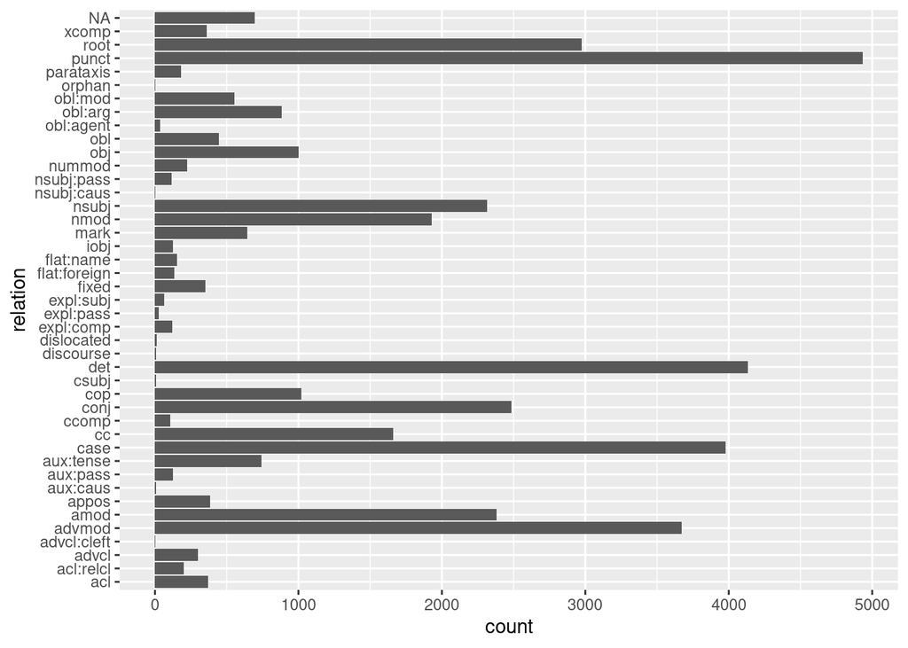

```r
annotate<-read_rds("annotation_Airbnb.rds")

ggplot(annotate,aes(x=relation))+geom_bar()+coord_flip()
```

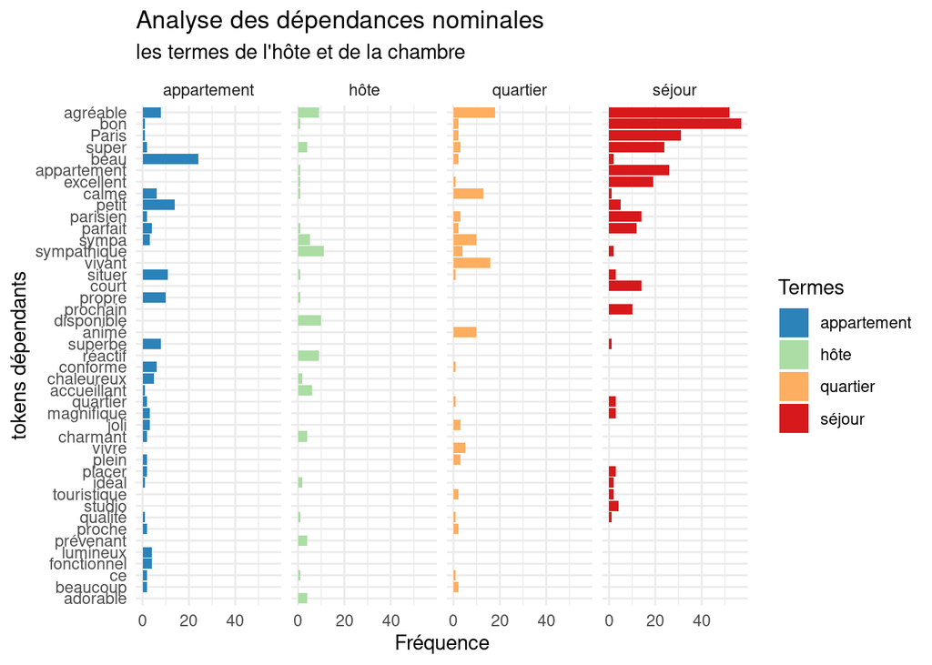

```r
#on met à niveau la racine
ann_racine<- annotate%>%
  left_join(annotate,by= c("doc_id"="doc_id", "sid"="sid", "tid_source"="tid"), suffix=c("", "_source"))
#on filtre les relation nominales puis celle qui concerne les termes cibles
foo<-ann_racine %>%
  filter(relation == "amod"|relation =="acl"|relation =="nmod"|relation =="appos") %>%
  select(doc_id = doc_id, start = lemma, word = lemma_source)%>%
    filter(word=="hôte"|word=="appartement"|word=="quartier"|word=="séjour",start!="Alice", start!="l’")%>%
  group_by(word,start)%>%
  mutate(n=1)%>%
  summarise(n=sum(n))
# On remet en forme les données
foo1<-dcast(foo, start ~  word)
foo1[is.na(foo1)] = 0

foo1$sum<- rowSums( foo1[,2:5])
foo1<-foo1 %>% filter(sum>3) %>%select(-sum)
foo1<-melt(foo1)


ggplot(foo1,aes(x=reorder(start,value), y=value, group=variable))+
  geom_bar(stat="identity",aes(fill=variable),position=position_dodge())+
  coord_flip()+
  scale_fill_brewer(palette="Spectral",direction = -1)+
  theme_minimal()+
  labs( title="Analyse des dépendances nominales", subtitle = "les termes de l'hôte et de la chambre", x="tokens dépendants", y="Fréquence", fill="Termes")+facet_wrap(vars(variable), ncol = 4)
```

# 3 *Sentiment analysis*

On va réaliser une analyse du sentiment du corpus. Pour cela, on utilise le dictionnaire des sentiments et émotions NRC, car il est disponible dans 40 langues, dont le français. Il existe d’autres dictionnaires de sentiments (positif vs négatif), par exemple AFINN ou BING, ainsi que des dictionnaires thématiques (LIWC par exemple), mais ils sont en anglais, donc utilisables pour des corpus en anglais.

Ici, on utilise le dictionnaire NRC à travers le package *syuzhet*. La fonction *get_nrc_sentiment* prend en entrée un vecteur de type caractère.

```r
library(syuzhet)


d<-get_nrc_sentiment(data$comments, language = "french")
summary(d, digits=0)
```

```
##      anger    anticipation    disgust       fear        joy        sadness
##  Min.   :0   Min.   :0     Min.   :0   Min.   :0   Min.   :0    Min.   :0
##  1st Qu.:0   1st Qu.:0     1st Qu.:0   1st Qu.:0   1st Qu.:1    1st Qu.:0
##  Median :0   Median :1     Median :0   Median :0   Median :1    Median :0
##  Mean   :0   Mean   :1     Mean   :0   Mean   :0   Mean   :1    Mean   :0
##  3rd Qu.:0   3rd Qu.:2     3rd Qu.:0   3rd Qu.:0   3rd Qu.:2    3rd Qu.:1
##  Max.   :6   Max.   :10    Max.   :5   Max.   :6   Max.   :10   Max.   :6
##     surprise     trust      negative     positive
##  Min.   :0   Min.   :0   Min.   :0    Min.   : 0
##  1st Qu.:0   1st Qu.:1   1st Qu.:0    1st Qu.: 2
##  Median :1   Median :2   Median :0    Median : 3
##  Mean   :1   Mean   :2   Mean   :1    Mean   : 4
##  3rd Qu.:1   3rd Qu.:3   3rd Qu.:1    3rd Qu.: 6
##  Max.   :5   Max.   :9   Max.   :10   Max.   :16
```

```r
data<-cbind(data,d)

data[600,]
```

```
##     ...1    X1   X1_1 listing_id        id       date reviewer_id reviewer_name
## 600  600 96537 491253    7480045 269370125 2018-05-27    39240018        Marion
##                                                                                        comments
## 600 Appartement cosy, propre et calme. Idéal pour se poser au milieu du cœur trépidant de paris
##     recence langue nbcar anger anticipation disgust fear joy sadness surprise
## 600     375 french    91     0            0       0    0   1       0        0
##     trust negative positive
## 600     1        1        5
```

Le dictionnaire comprend 10 variables, 8 émotions et 2 sentiments. Pour représenter les données, nous avons besoin de les transformer.

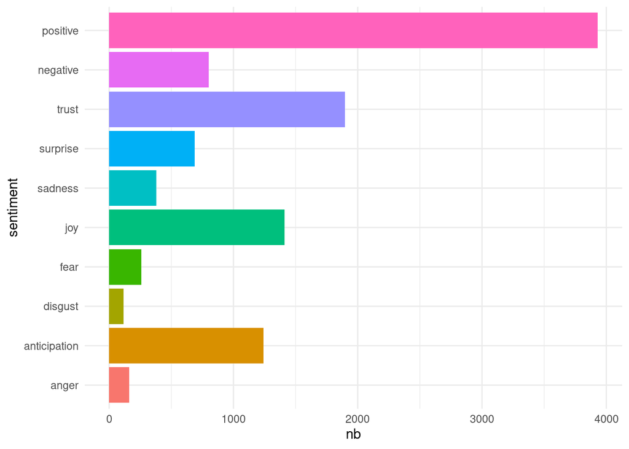

```r
e<-melt(d, variable.name = "sentiment", value.name = "nb")

ggplot(e, aes(sentiment, nb))+
  geom_col(aes(fill=sentiment),show.legend = FALSE)+
  theme_minimal()+
  coord_flip()
```

## 3.1 Les sentiments

Intéressons-nous d’abord aux sentiments :

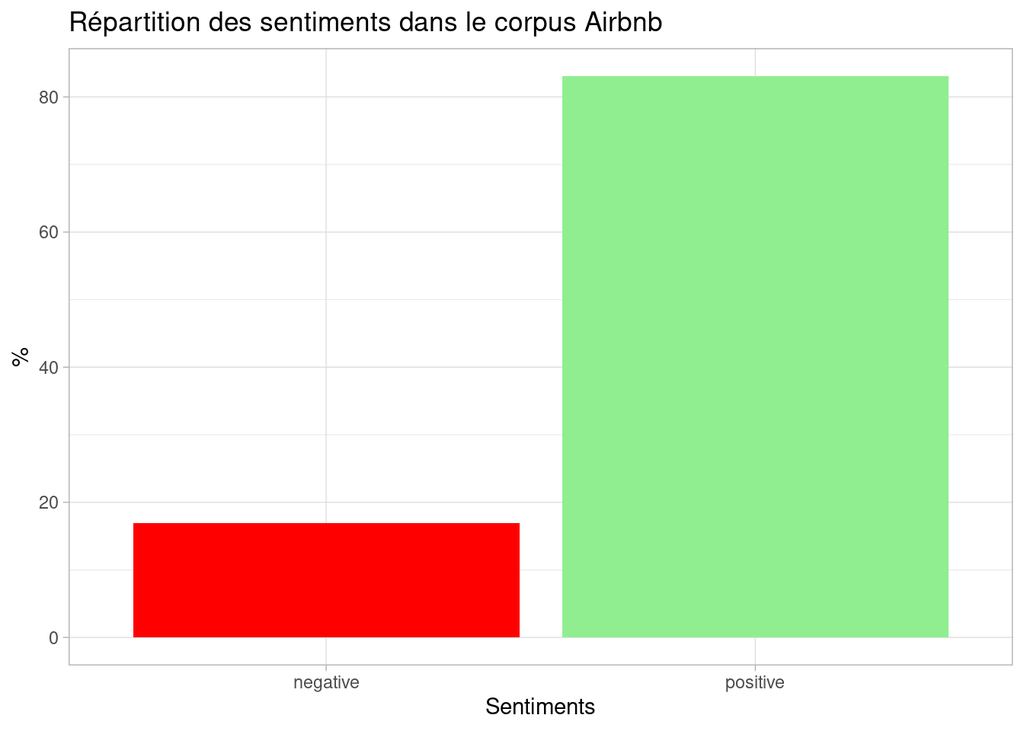

```r
sent<-subset(d, select=c(positive, negative))


sent2<-tibble(sentiment=c("positive", "negative"),   nb=c(sum(sent$positive), sum(sent$negative)))%>%
  mutate(prop=round( nb/sum(nb)*100, 2))

ggplot(data=sent2,  aes(x=sentiment, y=prop)) +
  geom_bar(stat="identity", aes(fill=sentiment), show.legend = FALSE) +
  xlab("Sentiments") +
  ylab("%")+
  ggtitle("Répartition des sentiments dans le corpus Airbnb")+
  scale_fill_manual(values=c("red", "lightgreen"))+
  theme_light()
```

Le corpus est très largement positif, ce qui n’est pas étonnant. On peut aussi créer d’autres indicateurs, comme la valence (différence positif-négatif) ou l’expressivité (somme de positif+négatif).

**Exercice :** personnalisez le graphique ci-dessous pour la variable d’expressivité.

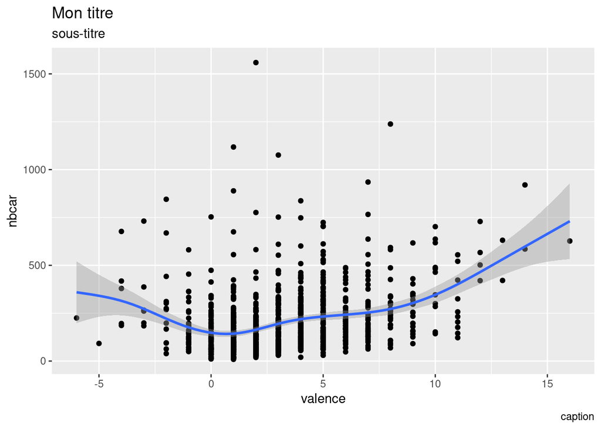

```r
data<-data%>%
  mutate(valence = positive-negative)

ggplot(data = data, aes(x = valence, y= nbcar))+
  geom_point()+
  geom_smooth()+
  labs(title="Mon titre", subtitle = "sous-titre", caption="caption")
```

## 3.2 Les émotions

Regardons maintenant ce qu’il en est de la répartition des émotions :

```r
#On crée d'abord une palette pour les émotions
emocol<-c("yellow","chartreuse","olivedrab3","green4","royalblue3","purple3","red3","orangered1")

#On récupère les émotions
emo<-subset(d,select=-c(positive, negative))
summary(emo)
```

```
##      anger       anticipation       disgust           fear
##  Min.   :0.00   Min.   : 0.000   Min.   :0.000   Min.   :0.00
##  1st Qu.:0.00   1st Qu.: 0.000   1st Qu.:0.000   1st Qu.:0.00
##  Median :0.00   Median : 1.000   Median :0.000   Median :0.00
##  Mean   :0.16   Mean   : 1.243   Mean   :0.117   Mean   :0.26
##  3rd Qu.:0.00   3rd Qu.: 2.000   3rd Qu.:0.000   3rd Qu.:0.00
##  Max.   :6.00   Max.   :10.000   Max.   :5.000   Max.   :6.00
##       joy            sadness         surprise         trust
##  Min.   : 0.000   Min.   :0.000   Min.   :0.000   Min.   :0.000
##  1st Qu.: 1.000   1st Qu.:0.000   1st Qu.:0.000   1st Qu.:1.000
##  Median : 1.000   Median :0.000   Median :1.000   Median :2.000
##  Mean   : 1.412   Mean   :0.381   Mean   :0.688   Mean   :1.895
##  3rd Qu.: 2.000   3rd Qu.:1.000   3rd Qu.:1.000   3rd Qu.:3.000
##  Max.   :10.000   Max.   :6.000   Max.   :5.000   Max.   :9.000
```

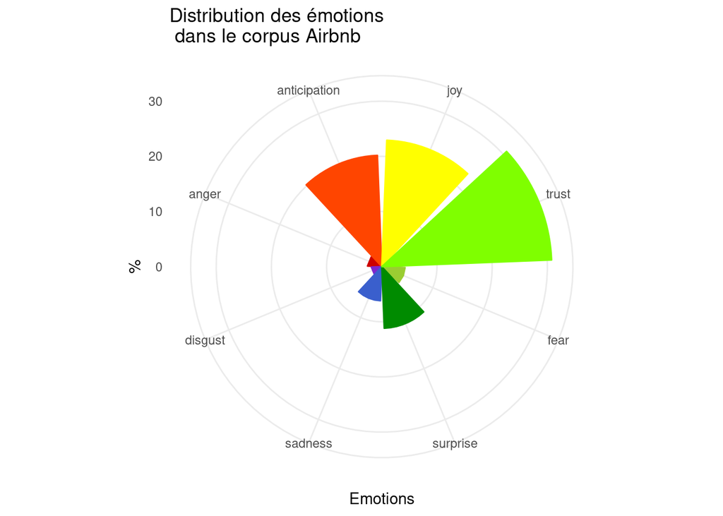

```r
#On transforme le tableau
# tibble(emotion=variable.names(emo), nb=apply(emo,2, sum))

emo2<-tibble(emotion=variable.names(emo), nb=c(sum(emo$anger),sum(emo$anticipation), sum(emo$disgust), sum(emo$fear), sum(emo$joy), sum(emo$sadness), sum(emo$surprise), sum(emo$trust)))%>%
  mutate(prop=nb/sum(nb)*100,
       emotion=factor(emotion, ordered = TRUE,levels = c("joy","trust","fear","surprise","sadness","disgust","anger","anticipation")))

#On crée un graphique circulaire
ggplot(data=emo2,  aes(x=emotion, y=prop, colour=emotion)) +
  geom_bar(stat="identity", aes(fill=emotion), show.legend = FALSE)+
  xlab("Emotions") +
  ylab("%") + ggtitle("Distribution des émotions \n dans le corpus Airbnb")  +
  coord_polar()+
  scale_color_manual(values=emocol)+ scale_fill_manual(values=emocol)+
  theme_minimal()
```

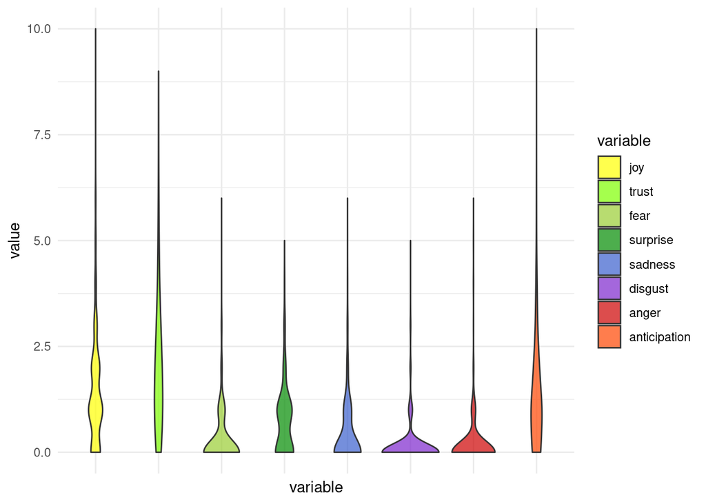

```r
#On regarde la réprtition des émotions dans le corpus :
emo3<-melt(emo)
emo3$variable<-factor(emo3$variable, ordered = TRUE,levels = c("joy","trust","fear","surprise","sadness","disgust","anger","anticipation"))
ggplot(na.omit(emo3), aes(x=variable, y=value))+
  geom_violin(aes(fill=variable), alpha=0.7,adjust = 2)+theme_minimal()+ scale_fill_manual(values=emocol)+
  scale_x_discrete(labels=NULL)
```

# 4 Évolution du corpus dans le temps

On va regarder comment les sentiments évoluent dans le temps. On doit tout d’abord créer une variable temporel dans notre jeu de données. Nous en avons déjà une, qui indique la date et l’heure à laquelle le commentaire a été posté. Nous allons la transformer pour regrouper les commentaires en fonction de l’année (on peut le faire pour les jours, les mois, les minutes, …). On utilise le package *lubridate*.

```r
library(lubridate)

data$year<-year(data$date)

data%>%group_by(year)%>%summarise('nb com'=n())
```

```
## # A tibble: 9 × 2
##    year `nb com`
##   <dbl>    <int>
## 1  2012        1
## 2  2013       10
## 3  2014       14
## 4  2015       83
## 5  2016      165
## 6  2017      236
## 7  2018      321
## 8  2019      167
## 9    NA        3
```

Regardons maintenant comment évolue les sentiments dans le temps :

```r
data$year<-as.factor(data$year)
names(data)
```

```
##  [1] "...1"          "X1"            "X1_1"          "listing_id"
##  [5] "id"            "date"          "reviewer_id"   "reviewer_name"
##  [9] "comments"      "recence"       "langue"        "nbcar"
## [13] "anger"         "anticipation"  "disgust"       "fear"
## [17] "joy"           "sadness"       "surprise"      "trust"
## [21] "negative"      "positive"      "valence"       "year"
```

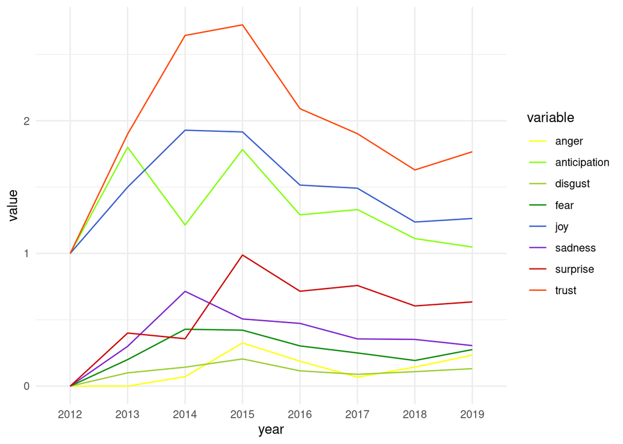

```r
gen_sent<-data%>%group_by(year)%>%summarise(across(13:20,~mean(.x, na.rm = T)))%>%na.exclude()

# gen_sent <-data%>%na.exclude()%>% group_by(year)%>%summarise(joy=mean(joy,na.rm = TRUE),
#                                                  trust=mean(trust,na.rm = TRUE),
#                                                  fear=mean(fear,na.rm = TRUE),
#                                                  surprise=mean(surprise,na.rm = TRUE),
#                                                  sadness=mean(sadness,na.rm = TRUE),
#                                                  disgust=mean(disgust,na.rm = TRUE),
#                                                  anger=mean(anger,na.rm = TRUE),
#                                                  anticipation=mean(anticipation,na.rm = TRUE))

gen_sent<-melt(gen_sent, by=year)

ggplot(gen_sent,aes(x=year, y=value,group=variable)) +
  geom_line(aes(color=variable), size=0.5) +
  theme_minimal()+
  scale_color_manual(values = emocol)
```

Maintenant, on va s’intéresser aux mots.

# 5 Nuage de mots comparés

## 5.1 En fonction des années

On refait les manipulations préliminaires :

```r
data2<-data%>%filter(!is.na(year))

corpus_airbnb<-corpus(data2, text_field = "comments")

tok<-tokens(corpus_airbnb, remove_punct = TRUE, remove_numbers = TRUE, remove_symbols = TRUE)%>%
  tokens_remove(stopwords("fr"))

dfm<-dfm(tok)
```

Comparons les mots en fonction des années :

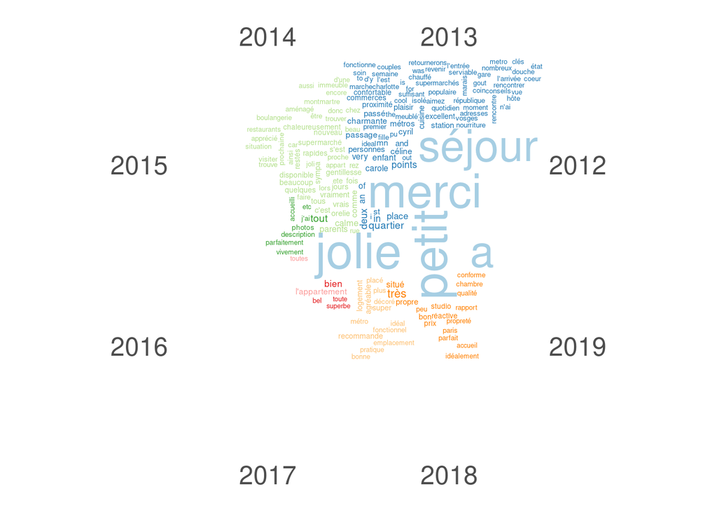

```r
dfmgp<-dfm_group(dfm, groups = year)

#On peut aussi passer la fonction directement en transformant en dfm avec l'option groups : dfm(tok, groups="year")

textplot_wordcloud(dfmgp, comparison=TRUE, max_words = 200)
```

## 5.2 En fonction des sentiments

Pour comparer en fonction des sentiments, il faut accéder au dictionnaire NRC (en français) (il y a des fonctions simplifiées pour les dictionnaires en anglais) :

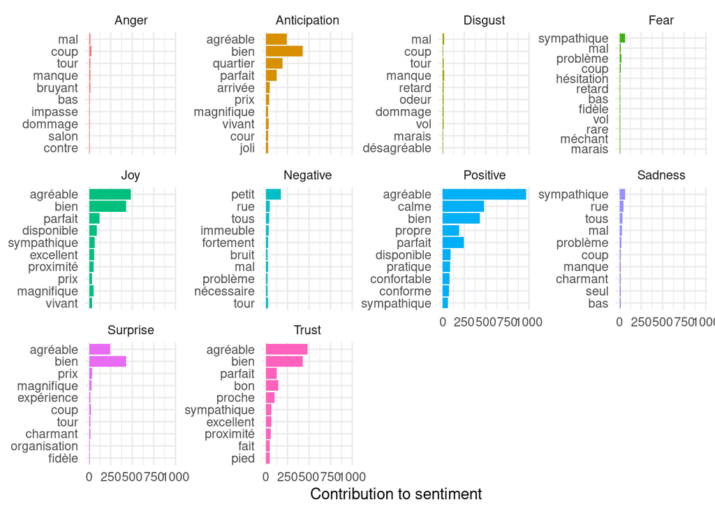

```r
dic_nrc<-read_xlsx("NRCfr.xlsx")%>%
gather(-word,key=sentiment, value=value)%>%
filter(value==1, word!="NO TRANSLATION")%>%
select(-value)


d<-broom::tidy(dfm)

sent<-inner_join(d,dic_nrc, by=c("column"="word"))

sent<-sent%>%group_by(sentiment)%>%count(column, sort=T)%>%ungroup()

sent %>%
  group_by(sentiment) %>%
  top_n(10) %>%
  ungroup() %>%
  mutate(term = reorder(column, n))%>%
  ggplot(aes(term, n, fill = sentiment)) +
  geom_col(show.legend = FALSE) +
  facet_wrap(~sentiment, scales = "free_y") +
  labs(y = "Contribution to sentiment",
       x = NULL) +
  coord_flip()+
  theme_minimal()
```

# 6 Mesure de l’antagonisme

On utilise le modèle wordfish qui permet, à partir de l’occurrence des mots, d’opposer les textes selon un unique axe. Voyons voir ce que cela donne :

```r
library(quanteda.textmodels)

wf <- textmodel_wordfish(dfmgp)
summary(wf)
```

```
##
## Call:
## textmodel_wordfish.dfm(x = dfmgp)
##
## Estimated Document Positions:
##         theta       se
## 2012 -0.85103 0.201764
## 2013  2.22960 0.007247
## 2014  0.28951 0.048843
## 2015  0.25650 0.021886
## 2016 -0.06718 0.017062
## 2017 -0.63775 0.010707
## 2018 -0.61143 0.009891
## 2019 -0.60822 0.013587
##
## Estimated Feature Scores:
##        j'ai  passé semaines studio chaleureux allures  chalet montagne
## beta 0.1281 0.2212  -0.6688 -3.347     0.1066 -0.3157 -0.3157  -0.3157
## psi  1.8080 2.6178  -1.1983  1.025     1.8019 -2.1790 -2.1790  -2.1790
##      véronique    hôte accueillante attentionnée    rend  séjour  encore   plus
## beta   -0.2342 0.04318      -1.3409     -0.54007 -0.6373 0.03148 -0.6772 -1.536
## psi    -0.5431 2.59683       0.8737      0.04913 -1.1876 3.72295  1.3638  2.050
##      agréable    peux recommander     c'est deuxième    fois j'occupe    joli
## beta  -0.1326 -0.7014     -0.7678 -0.007753  -1.2509 -0.4752  -0.2943 -0.8326
## psi    3.4366 -1.2093      0.9653  2.029103  -0.5506  0.7640  -2.1720  0.7384
##      appartement    très disponible l'appartement spacieux    tres
## beta     -0.1549 -0.1017    -0.1571        -0.265  0.08418 -0.9254
## psi       3.8865  4.9508     2.3829         3.483  1.83714  1.5859
```

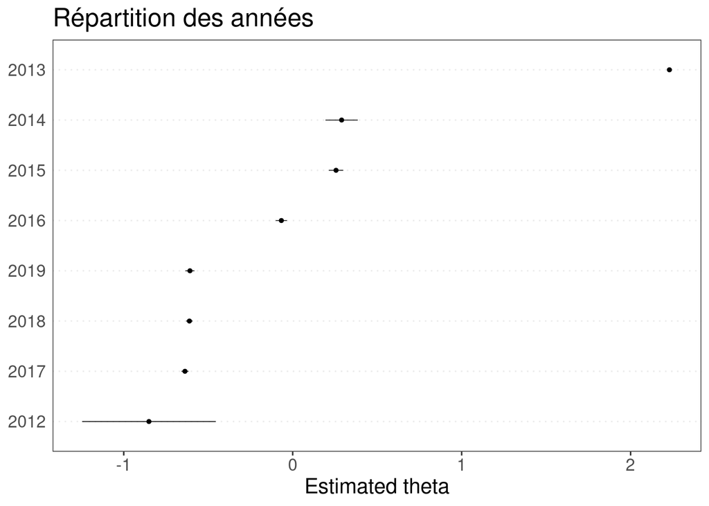

```r
textplot_scale1d(wf)+
theme(text = element_text(size=15))+
ggtitle("Répartition des années")
```

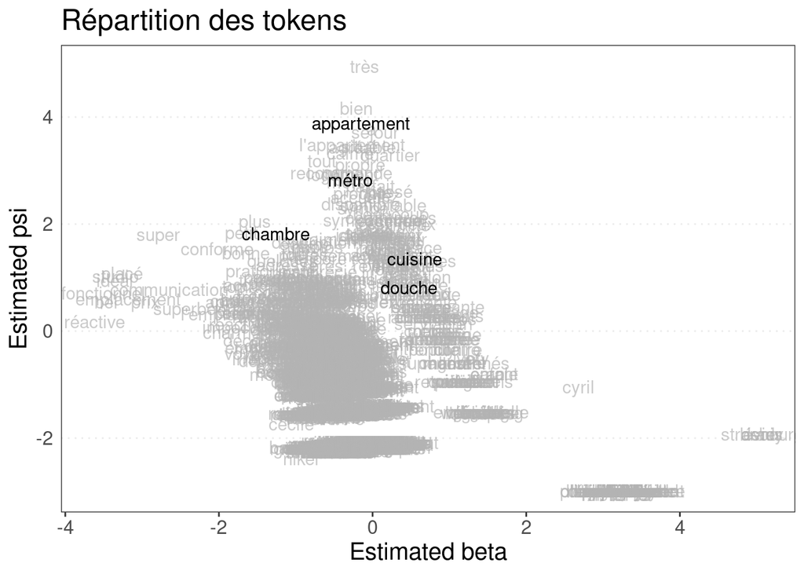

```r
textplot_scale1d(wf, margin = "features",
groups = "year",
highlighted = c("appartement","chambre","métro","douche","cuisine"))+
theme(text = element_text(size=15))+
ggtitle("Répartition des tokens")
```